# Chapter 4

R for physicians

2025-11-28

| Author |  |
| --- | --- |
| Name | Claire Descombes |
| Affiliation | Universitätsklinik für Neurochirurgie, Inselspital Bern |
| Degree | MSc Statistics and Data Science, University of Bern |
| Contact | claire.descombes@insel.ch |

The reference material for this course, as well as some useful literature to deepen your knowledge of R, can be found at the bottom of the page.

To explore R’s statistical tools, we’ll continue working with the NHANES datasets. Specifically, we’ll use the merged data frame that combines the `demo`, `bpx`, `bmx` and `smq` data sets. If you still have it loaded from Chapters 2 und 3, you can use it directly. Otherwise, you can download it from the [`data_sets` folder](https://github.com/ClaireMargaux/rforphysicians/tree/main/data_sets) and import it into R.

To be able to use survival data, we will also need the NHANES data set complemented with mortality data. If you still have it loaded from Chapters 3, you can use it directly. Otherwise, you can download it from the [`data_sets` folder](https://github.com/ClaireMargaux/rforphysicians/tree/main/data_sets) and import it into R.

```r
# Load the merged_nhanes CSV file
merged_nhanes <- read.csv("C:/GitHub/rforphysicians/data_sets/merged_nhanes.csv")

# Load the merged_nhanes_with_mort CSV file
merged_nhanes_with_mort <- read.csv("C:/GitHub/rforphysicians/data_sets/merged_nhanes_with_mort.csv")
```

# 1 Most commonly used statistical tests and models

This chapter will follow the structure outlined below. We will learn how to perform a selection of statistical tests and models in R, categorising them by their objective (e.g. comparing two means or analysing survival).

| Section | Topic | Subtopics |
| --- | --- | --- |
| **4.1 Tests for comparing two groups** | Tests comparing means or proportions between two groups | • Continuous variables: Student’s t-test, Z-test, Wilcoxon rank-sum and signed-rank tests • Categorical variables: Chi-square test, Fisher’s exact test, McNemar’s test, Cochran’s Q test |
| **4.2 Tests for more than two groups** | Tests for comparing multiple groups | • Continuous variables: One-way ANOVA, Repeated-measures ANOVA, Kruskal-Wallis test, Friedman test |
| **4.3 Tests for distribution and normality** | Tests for distribution of data | • Shapiro-Wilk test, Kolmogorov–Smirnov test, Lilliefors test |
| **4.4 Tests for survival analysis** | Tests for time-to-event data | • Log-Rank test |
| **4.5 Correlation and association tests** | Tests for relationships between variables | • Correlation test by Pearson • Correlation test by Spearman |
| **4.6 Regression** | Predictive models and regression techniques | • Generalized Linear Models (GLMs): Linear regression, logistic regression • Cox (proportional hazards) regression |

## 1.1 Which test for which data?

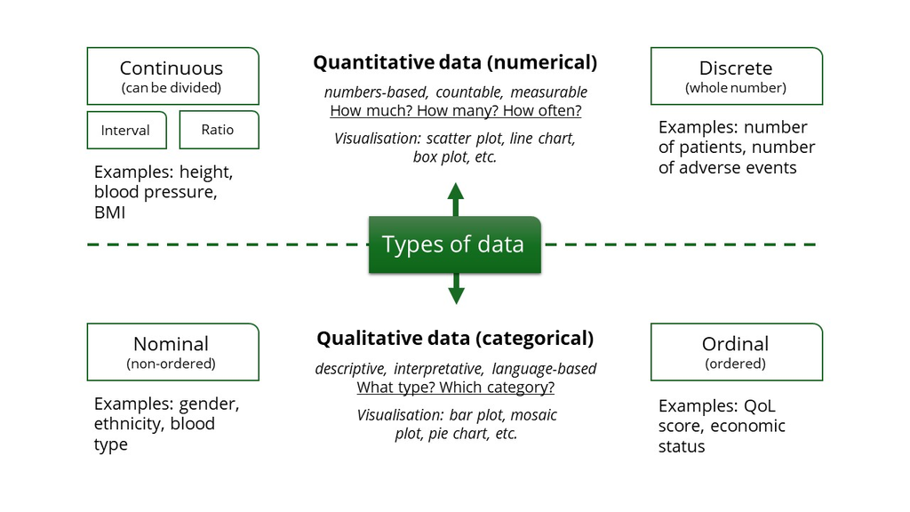

Before we begin, here is an overview of the type of data required by each test/model. More tests and models are presented than will be discussed in the course, but I have included them for the sake of completeness. If you feel lost on that topic at any point in the chapter, just scroll up again to have a look at this table.

|  | 1 sample | 2 paired samples | 2 unpaired samples | >2 paired samples | >2 unpaired samples | Continuous predictor |
| --- | --- | --- | --- | --- | --- | --- |
| **Binary** | • Binomial test | • McNemar test | • Chi-square test • Fisher’s exact test |  |  | • Logistic regression |
| **Nominal** | • Chi-square goodness of fit test | • Cochran’s Q test | • Chi-square test • Extensions of Fisher’s test |  |  | • Multinomial regression |
| **Ordinal** | • One-sample Wilcoxon signed-rank test • One-sample Sign test | • Wilcoxon signed-rank test • Sign test | • Wilcoxon rank-sum test | • Friedman test | • Kruskal–Wallis test | • Ordinal regression |
| **Continuous** | • One-sample t-test | • Paired t-test • Wilcoxon signed-rank test | • Two-sample t-test | • Repeated-measures ANOVA | • One-way ANOVA | • Linear regression |
| **Time-to-event** | • One-sample log-rank test |  | • Log-Rank test |  |  | • Cox regression • Weibull regression |

## 1.2 What is a statistical test?

Before we start looking at many different statistical hypothesis tests, let us recall the basic structure that they all share, by exploring more in-depth the Student’s t-test for two, independent continuous samples.

| Generally | Student’s t-test for two, independent samples |
| --- | --- |
| A test always aims to put to test a claim we make about some parameter (a correlation, a difference in mean, etc.) in the distribution of the population of interest. | Working on two patients cohorts, the smokers and the non-smokers, one could ask her-/himself if they share the same mean on a continuous variable, e.g. the BMI |
| The data itself is expected to fulfil some **assumptions**. | As the BMI data is continuous, the cohorts are big (> 100 patients each, of sizes $n_1$ and $n_2$) and assumed to be independent, and there is no reason to assume they’d have a different variance in t… |
| The ‘status quo’/no difference formulation of the question we’re asking is called the **null hypothesis**. | The null hypothesis, in our example, is the hypothesis that our two cohorts (the smokers and the non-smokers) share the same mean BMI |
| The hypothesis we are usually interested to prove, the one showing a difference between two quantities, is called the **alternative hypothesis** | The alternative hypothesis, in our example, is the hypothesis that our two cohorts (the smokers and the non-smokers) do not share the same mean BMI |
| Assuming the null hypothesis is true, a specific parameter, called the **statistic**, is expected to fall into a given **distribution** | If the null hypothesis is true, then the t statistic: $$t = \frac{\tilde{X}_1-\tilde{X}_2}{s_p \cdot \sqrt{\frac{1}{n_1}+\frac{1}{n_2}}}$$ (where $s_p$ is the pooled standard deviation) follows a Stud… |
| For any object of which the distribution is (assumed to be) known, it is possible to compute its probability to fall within a certain range; for a given **significance level** (denoted by $\alpha$) an… | Letting $\alpha$ be 0.05, as it is common in medicine, we can determine that our t statistic has a probability of 95% to be in a given interval (that can be computed in R or using a table). |
| If the statistic, after being computed, falls in the $1-\alpha$ confidence interval ($p>\alpha$), then we **cannot reject the null hypothesis**, and have to look for further evidence to prove our clai… | If the t statistic falls into the range we computed, then we cannot say that we saw a significant difference in the means. |
| If the statistic, after being computed, does *not* fall in the $1-\alpha$ confidence interval ($p \leq \alpha$), then we can reject the null hypothesis, and say that the claim we made on the data is *… | If the t-statistic does not fall into the range we computed, then we can say that we observe a statistically significant difference in the means, with a confidence of 95%. |

A few important comments:

- The p-value is the **probability under the null hypothesis** of obtaining a (real-valued) test statistic **at least as extreme** as the one obtained.
- Loosely speaking, rejection of the null hypothesis implies that there is **sufficient evidence against it**.
- It is not possible to prove that the null hypothesis is true: it could always be that with a bigger effect size and/or a larger sample size, we could statistically show the difference that we are trying to demonstrate. So, when a test comes out “negatively” (no statistical significance, $p>\alpha$), it does not mean that our claim is necessarly wrong.
- On the other hand, even a significant test ($p\leq\alpha$) does not mean that we *irrefutably proved* our claim: in a theoretical world, where we could repeat our experiment 100 times in the same conditions and on the same population, even if our theory is wrong, we would always find a “positive” result ($p\leq\alpha$) in $\alpha\%$ of the cases. That is why consensus, in science, always relies on repeated experiments that (for the vast majority of them*) draw the same conclusion.
- * Why is that? Because again, even in a theoretical world, where we could repeat our experiment 100 times in the same conditions, even if our theory is right, we would always find a “negative” result in $\alpha\%$ of the cases.

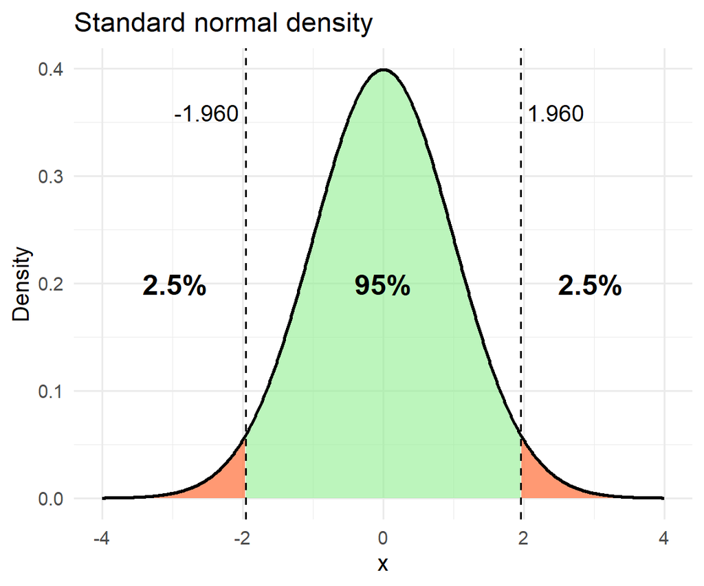

# 2 Tests for comparing two groups

## 2.1 Continuous variables

### 2.1.1 Student’s t-test

Parametric test used to evaluate whether the mean of two continuous variables is statistically significant or not. It provides an exact test for the equality of the means of two i.i.d. normal populations with unknown, but equal, variances.

1. Null hypothesis

- Means of two groups are equal

2. Type of data

- One or two vectors of continuous variables (e.g. blood pressure in mmHg in two cohorts)

3. Requirements

- Both samples are *approximately normally distributed*. Under weak assumptions, this follows in large samples from the central limit theorem, even when the distribution of observations in each group is non-normal.
- If using Student’s original definition of the t-test, the two populations being compared should have the *same variance* (assessable graphically using a Q–Q plot). If the sample sizes in the two groups being compared are equal, Student’s original t-test is highly robust to the presence of unequal variances. *Welch’s t-test* is insensitive to equality of the variances regardless of whether the sample sizes are similar.
- The data used to carry out the test should either be *sampled independently* from the two populations being compared or be fully paired. This is in general not testable from the data, but if the data are known to be dependent (e.g. paired by test design), a paired test has to be applied.

💡 Independent samples are randomly selected so that their observations are not dependent on the values of other observations.

4. R function

`t.test(x, ...)`: Performs one and two sample t-tests on vectors of data.

5. Important arguments

```
t.test(x, y = NULL,
       alternative = c("two.sided", "less", "greater"),
       mu = 0, paired = FALSE, var.equal = FALSE,
       conf.level = 0.95, ...)
```

- `x, y`: the vector(s) that contain the data (only one vector in the case of a one-sample t-test, two vectors otherwise).
- `alternative`: a character string specifying the alternative hypothesis, must be one of “two.sided” (default), “greater” or “less”.
- `mu`: a number indicating the true value of the mean (or difference in means if you are performing a two sample test).
- `paired`: a logical indicating whether you want a paired t-test.
- `var.equal`: a logical variable indicating whether to treat the two variances as being equal. If `TRUE` then the pooled variance is used to estimate the variance otherwise the Welch (or Satterthwaite) approximation to the degrees of freedom is used.
- `conf.level`: confidence level of the interval (default: 0.95).

💡 “paired” means there is an obvious and meaningful one-to-one correspondence between the data in the first set and the data in the second set, e.g. blood pressure in a set of patients before and after administering a medicine.

6. Example

Let us test if the mean BMI (`BMXBMI`) is significantly different between men and women (`RIAGENDR`).

```r
# We quickly check the distribution of the BMI using a Q-Q-plot (even though,
# with such a large sample, this isn't required)
qqnorm(y = merged_nhanes$BMXBMI)
```

[output not shown]

```r
# We will learn more on Q-Q-plots under "Assessments of distribution and normality"

# We create two vectors, with the BMIs of women and men
bmi_women <- merged_nhanes$BMXBMI[merged_nhanes$RIAGENDR == "Female"]
bmi_men <- merged_nhanes$BMXBMI[merged_nhanes$RIAGENDR == "Male"]

# We can start looking at how many non NA entries we have and by computing the means
sum(!is.na(bmi_women));sum(!is.na(bmi_men))
```

```
## [1] 3239
```

```
## [1] 3212
```

```r
mean(bmi_women, na.rm = TRUE);mean(bmi_men, na.rm = TRUE)
```

```
## [1] 28.35542
```

```
## [1] 27.34091
```

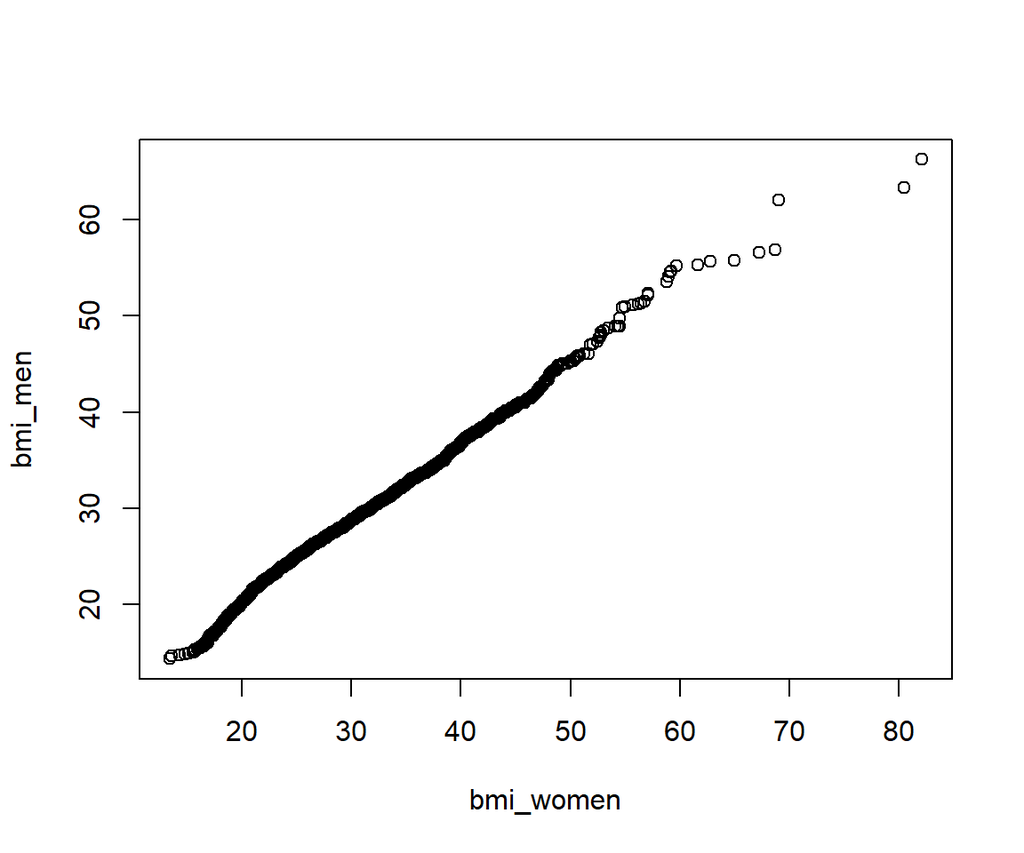

```r
qqplot(x = bmi_women, y = bmi_men)
```

```r
# We compare their means using a t-test
t.test(x = bmi_women, y = bmi_men, alternative = 'two.sided', var.equal = TRUE, paired = FALSE)
```

```
##
##  Two Sample t-test
##
## data:  bmi_women and bmi_men
## t = 5.8288, df = 6449, p-value = 5.854e-09
## alternative hypothesis: true difference in means is not equal to 0
## 95 percent confidence interval:
##  0.6733092 1.3557093
## sample estimates:
## mean of x mean of y
##  28.35542  27.34091
```

- The `t` value is the statistic of the t-test.
- `df` are the degrees of freedom (a characteristics of the underlying distribution of the statistic), depends on the test used (one- or two-sample, paired or unpaired), in this case it is the sum of the two samples minus 2 (3239+3212-2=6449).
- The `p-value` is the probability of getting such a `t` value under the null hypothesis. It is very small: 5.854e-09, so to an $\alpha$-level of 0.05, we say that their is a statistically significant difference between the means of the two groups.
- The 95% CI tells us where the difference in the means lies, to a confidence of 95%. In coherence with the very low p-value, this interval does not contain 0 (which would mean “no difference”).
- Finally, the means of both vectors are also computed.

💡 `qqnorm` is a function that produces a normal Q-Q-plot of the values in y. `qqplot` produces a Q-Q-plot of two datasets.

#### 2.1.1.1 Z-test

The z-test is similar to the t-test (continuous variable(s), independent and normally distributed), and its null hypothesis is also that the means of two groups are equal, but it requires to know the standard deviation of your group(s).

You should favour a z-test to a t-test if the **standard deviation** of the group is **known** and the sample size is greater than or equal to 30.

There is no z-test function available in base R, but in packages like `BSDA` (`z.test(x, ...)`).

### 2.1.2 Wilcoxon rank-sum and signed-rank tests

Non-parametric (= makes minimal assumptions about the underlying distribution of the data being studied) “alternative” to the t-test (we do not test exactly the same thing, the t-test compares means, the Wilcoxon test compares distributions).

💡 If working on *paired data*, the test is called **Wilcoxon signed-rank test**, and on *unpaired data* it is called **Wilcoxon rank-sum test** (also called Mann–Whitney U test, Mann–Whitney–Wilcoxon test, or Wilcoxon–Mann–Whitney test).

1. Null hypothesis

- Distributions of both groups are identical (there is not one sample that stochastically dominates the other sample)

2. Type of data

- One or two vectors of continuous or ordinal variables (e.g. pain levels in two cohorts)

3. Requirements

- The data used to carry out the test should either be *sampled independently* from the two populations being compared or be fully paired. This is in general not testable from the data, but if the data are known to be dependent (e.g. paired by test design), a paired test has to be applied.
- The differences between paired observations should be *symmetrically distributed* around the median. Unlike the paired t-test, the Wilcoxon test does not require normality but works best when the distribution is roughly symmetric.

4. R function

`wilcox.test(x, ...)`: Performs one- and two-sample Wilcoxon tests on vectors of data; the latter is also known as ‘Mann-Whitney’ test.

5. Important arguments

```
wilcox.test(x, y = NULL,
            alternative = c("two.sided", "less", "greater"),
            mu = 0, paired = FALSE, exact = NULL, correct = TRUE,
            conf.int = FALSE, conf.level = 0.95,
            tol.root = 1e-4, digits.rank = Inf, ...)
```

- `x, y`: the vector(s) that contain the data (only one vector in the case of a one-sample Wilcoxon test, two vectors otherwise).
- `alternative`: a character string specifying the alternative hypothesis, must be one of “two.sided” (default), “greater” or “less”.
- `mu`: a number specifying an optional parameter used to form the null hypothesis. Set `mu = 0` (default) to test if the samples have the same distribution.
- `paired`: a logical indicating whether you want a paired test. If only x is given, or if both x and y are given and paired is TRUE, a **Wilcoxon signed rank test** of the null that the distribution of x (in the one sample case) or of x - y (in the paired two sample case) is symmetric about mu is performed. Otherwise, if both x and y are given and paired is FALSE, a **Wilcoxon rank sum test** (equivalent to the Mann-Whitney test: see the Note) is carried out. In this case, the null hypothesis is that the distributions of x and y differ by a location shift of mu and the alternative is that they differ by some other location shift.
- `conf.level`: confidence level of the interval (default: 0.95).

6. Example

Let us test if the distribution of the BMI (`BMXBMI`) is significantly different between men and women (`RIAGENDR`).

```r
# We create two vectors, with the BMIs of women and men
bmi_women <- merged_nhanes$BMXBMI[merged_nhanes$RIAGENDR == "Female"]
bmi_men <- merged_nhanes$BMXBMI[merged_nhanes$RIAGENDR == "Male"]

# We compare their distributions using a Wilcoxon test
wilcox.test(x = bmi_women, y = bmi_men, alternative = 'two.sided', mu = 0, paired = FALSE)
```

```
##
##  Wilcoxon rank sum test with continuity correction
##
## data:  bmi_women and bmi_men
## W = 5464414, p-value = 0.0004466
## alternative hypothesis: true location shift is not equal to 0
```

- The `W` value is the statistic of the Wilcoxon test (also called `U` statistic).
- The `p-value` is the probability of getting such a `W` value under the null hypothesis. It is very small: 0.0004466, so to an $\alpha$-level of 0.05, we say that their is a statistically significant difference between the distributions of the two groups.

## 2.2 Categorical variables

### 2.2.1 Chi-square test and Fisher’s exact test

Both are non-parametric tests used in the analysis of contingency tables. They evaluate the difference between observed categorical data and expected categorical data (assumed randomly distributed) to determine if there is a significant difference or relationship between variables.

The Chi-square test can be used when the sample sizes are large, Fisher’s exact test is valid for all sample sizes (even though in practice it is usually employed when sample sizes are small).

One can also test whether the observed proportions for a categorical variable differ from hypothesized proportions: this is called a Chi-square goodness of fit test.

1. Null hypothesis

- There are no differences between the classes in the population (rows and columns are independent)

2. Type of data

- Two categorical variables (e.g. cohort/control and progression of tumour yes/no)

3. Requirements

- Use Fisher’s exact test when the *expected count* in one or more of the cells in your contingency table is below 5.

💡 The expected counts are what we expect the numbers in the table to look like if the categorical variables are independent. The excepted count in a cell is always given by the formula:
$$\text{expected count} = \frac{\text{sum of row}
\cdot \text{sum of column}}{\text{total of table}}$$

Here an example:

**Observed frequencies table**

|  | Smoking | Non-smoking | Total |
| --- | --- | --- | --- |
| Female | 406 | 473 | 879 |
| Male | 659 | 737 | 1396 |
| Total | 1065 | 1210 | 2275 |

**Expected frequencies table**

|  | Smoking | Non-smoking | Total |
| --- | --- | --- | --- |
| Female | 411.49 | 467.51 | 879 |
| Male | 653.51 | 742.49 | 1396 |
| Total | 1065 | 1210 | 2275 |

4. R function

`chisq.test(x, ...)`: performs chi-square contingency table tests and goodness-of-fit tests.

`fisher.test(x, ...)`: performs Fisher’s exact test for testing the null of independence of rows and columns in a contingency table with fixed marginals.

5. Important arguments

```
chisq.test(x, y = NULL, correct = TRUE,
           p = rep(1/length(x), length(x)), rescale.p = FALSE,
           simulate.p.value = FALSE, B = 2000)
```

- `x`: a numeric vector or matrix. `x` and `y` can also both be factors.
- `y`: a numeric vector; ignored if x is a matrix. If `x` is a factor, `y` should be a factor of the same length.

```
fisher.test(x, y = NULL, workspace = 200000, hybrid = FALSE,
            hybridPars = c(expect = 5, percent = 80, Emin = 1),
            control = list(), or = 1, alternative = "two.sided",
            conf.int = TRUE, conf.level = 0.95,
            simulate.p.value = FALSE, B = 2000)
```

- `x`: either a two-dimensional contingency table in matrix form, or a factor object.
- `y`: a factor object; ignored if x is a matrix.
- `alternative`: a character string specifying the alternative hypothesis, must be one of “two.sided” (default), “greater” or “less”. Only used in the $2\times2$ case.
- `conf.int`: logical indicating if a confidence interval for the odds ratio in a $2\times2$ table should be computed (and returned).
- `conf.level`: confidence level for the returned confidence interval. Only used in the $2\times2$ case and if `conf.int = TRUE`.

6. Example

Let us test if the smoking status (`SMQ040`) is significantly different between men and women (`RIAGENDR`).

```r
# First, let us categorize the participants in smoking and non smoking
table(merged_nhanes$SMQ040)
```

```
##
##  Every day Not at all    Refused  Some days
##        878       1210          2        187
```

```r
merged_nhanes$SMOKE <- case_when(
  merged_nhanes$SMQ040 == "Not at all" ~ "No",
  merged_nhanes$SMQ040 %in% c("Every day", "Some days") ~ "Yes",
  merged_nhanes$SMQ040 == "Refused" ~ NA
)

# Let us visualize the contingency table
(tab <- table(merged_nhanes$SMOKE, merged_nhanes$RIAGENDR))
```

```
##
##       Female Male
##   No     473  737
##   Yes    406  659
```

```r
# What are the expected cell counts in this case?
chisq <- chisq.test(tab)
round(chisq$expected,2)
```

```
##
##       Female   Male
##   No  467.51 742.49
##   Yes 411.49 653.51
```

```r
# Since all cells are >5, we can test the null hypothesis of independence using
# a chi-square test
chisq.test(tab)
```

```
##
##  Pearson's Chi-squared test with Yates' continuity correction
##
## data:  tab
## X-squared = 0.18526, df = 1, p-value = 0.6669
```

```r
# Let us also try to run a Fisher's exact test on the same table
fisher.test(tab)
```

```
##
##  Fisher's Exact Test for Count Data
##
## data:  tab
## p-value = 0.6661
## alternative hypothesis: true odds ratio is not equal to 1
## 95 percent confidence interval:
##  0.8764221 1.2383671
## sample estimates:
## odds ratio
##   1.041726
```

- As it was to be expected (the table of observed and expected frequencies were very similar), the Chi-Square test is non significant (`p-value` = 0.6669).
- Same conclusion for Fisher’s exact test. The `estimate` given is an estimation of the odds ratio (only computed in the $2\times2$ case), with a corresponding `95% percent confidence interval`. Note that the $95\%$ confidence interval for the odds ratio contains 1 and that the `p-value` is above 0.05, which is coherent.
- The `X-squared` is the statistic of the Chi-square test (assumed to have a chi-square distribution with `df` degrees of freedom).
- For Fisher’s exact test, the statistic is assumed to have a hypergeometric distribution.

#### 2.2.1.1 McNemar’s test, Cochran’s Q test

McNemar’s test is similar to the Chi-square test ($2\times 2$ contingency table), and its null hypothesis is also that the variables are independent, but it is used on **paired** categorical data. It is often used in practice to compare the sensitivities and specificities for the evaluation of two diagnostic tests on the same group of patients.

The corresponding function in base R is called `mcnemar.test(x,...)`.

The Cochran’s Q test is an extension of the McNemar’s test for more than two categories with paired responses ($n\times 2$ contingency table).

There is no function for a Cochran’s Q test in base R, but some packages (`onewaytests`, `outliers`, etc.) can provide one.

# 3 Tests for more than two groups

## 3.1 Continuous variables

### 3.1.1 One-way ANOVA (Analysis of Variance)

The one-way ANOVA is used as an extension to the t-test for differences among at least three groups. When there are only two means to compare, the t-test and the F-test (conducted by the one-way ANOVA) are equivalent.

1. Null hypothesis

- Means of different groups are equal

2. Type of data

- Vectors of continuous variables (e.g. blood pressure in mmHg in different cohorts)

3. Requirements

- The different samples are *approximately normally distributed*. Under weak assumptions, this follows in large samples from the central limit theorem, even when the distribution of observations in each group is non-normal.
- The groups being compared should have the *same variance*. If this is not the case, an approximate method of Welch (1951) can be used, which generalizes the commonly known 2-sample Welch test to the case of arbitrarily many samples.
- The data used to carry out the test should either be *sampled independently* from the populations being compared. ANOVA is not robust to violations to the assumption of independence.

4. R function

`oneway.test(formula, data, ...)`: Test whether two or more samples from normal distributions have the same means.

5. Important arguments

```
oneway.test(formula, data, subset, na.action, var.equal = FALSE)
```

- `formula`: a formula of the form `lhs ~ rhs` where `lhs` gives the sample values and `rhs` the corresponding groups.
- `data`: an optional matrix or data frame containing the variables in the formula formula.
- `na.action`: a function which indicates what should happen when the data contain NAs.
- `var.equal`: a logical variable indicating whether to treat the variances in the samples as equal. If `TRUE`, then a simple F test for the equality of means in a one-way analysis of variance is performed. If `FALSE`, an approximate method of Welch (1951) is used, which generalizes the commonly known 2-sample Welch test to the case of arbitrarily many samples.

6. Example

Let us test if the mean blood pressure at first reading (`BPXSY1`) is significantly different between different age groups (`RIDAGEYR`).

```r
# We first define different age groups to compare them to each other
merged_nhanes <- merged_nhanes %>%
  mutate(AGE_GROUP = cut(RIDAGEYR, breaks = seq(10, 80, 10)))

# Let us have a look at the mean BP values (1st reading) for those groups
merged_nhanes %>%
  group_by(AGE_GROUP) %>%
  summarise(
    n = n(),
    mean_BPXSY1 = mean(BPXSY1, na.rm = TRUE)
  )
```

| AGE_GROUP | n | mean_BPXSY1 |
| --- | --- | --- |
| (10,20] | 1343 | 110.0211 |
| (20,30] | 939 | 113.8345 |
| (30,40] | 928 | 116.6714 |
| (40,50] | 881 | 120.4581 |
| (50,60] | 887 | 127.7841 |
| (60,70] | 833 | 132.3541 |
| (70,80] | 738 | 138.4203 |

```r
# Let us now test the means using a one-way ANOVA
oneway.test(BPXSY1 ~ AGE_GROUP, data = merged_nhanes)
```

```
##
##  One-way analysis of means (not assuming equal variances)
##
## data:  BPXSY1 and AGE_GROUP
## F = 345.07, num df = 6.0, denom df = 2471.4, p-value < 2.2e-16
```

#### 3.1.1.1 Repeated-measures ANOVA

Repeated measures ANOVA is the equivalent of the one-way ANOVA, but for related, not independent groups, and is the extension of the paired t-test.

It can be performed in R using the function `anova_test(data, formula, ...)`.

### 3.1.2 Kruskal-Wallis test

Extension of the Wilcoxon rank-sum test for more than two groups.

1. Null hypothesis

- Distributions of the different groups are identical (there is not one sample that stochastically dominates one other sample)

2. Type of data

- Vectors of continuous or ordinal variables (e.g. pain levels in different cohorts)

3. Requirements

- The data used to carry out the test should be *sampled independently* from the populations being compared. If the data are known to be paired, a Friedman test has to be applied.
- The observations in each group should follow *similar distributions*.

4. R function

`kruskal.test(formula, data, subset, na.action, ...)`: Performs a Kruskal-Wallis rank sum test.

5. Important arguments

```
kruskal.test(formula, data, subset, na.action, ...)
```

- `formula`: a formula of the form `response ~ group` where response gives the data values and group a vector or factor of the corresponding groups.
- `data`: a matrix or data frame containing the variables in the formula formula.
- `na.action`: a function which indicates what should happen when the data contain NAs.

6. Example

Let us test if the mean blood pressure at first reading (`BPXSY1`) is significantly different between different age groups (`RIDAGEYR`), just like we did with the one-way ANOVA.

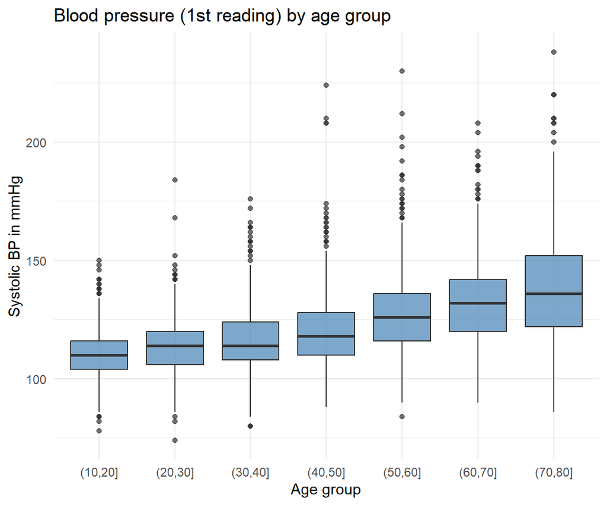

```r
# We first define different age groups to compare them to each other
merged_nhanes <- merged_nhanes %>%
  mutate(AGE_GROUP = cut(RIDAGEYR, breaks = seq(10, 80, 10)))

# Let us have a look at the distributions of the BP values (1st reading) for those groups
ggplot(merged_nhanes, aes(x = AGE_GROUP, y = BPXSY1)) +
  geom_boxplot(fill = "steelblue", alpha = 0.7) +
  labs(
    x = "Age group",
    y = "Systolic BP in mmHg",
    title = "Blood pressure (1st reading) by age group"
  ) +
  theme_minimal()
```

```r
# Let us now test the distributions using a Kruskal-Wallis test
kruskal.test(BPXSY1 ~ AGE_GROUP, data = merged_nhanes)
```

```
##
##  Kruskal-Wallis rank sum test
##
## data:  BPXSY1 by AGE_GROUP
## Kruskal-Wallis chi-squared = 1623.4, df = 6, p-value < 2.2e-16
```

- The `Kruskal-Wallis chi-squared` value is the statistic of the Kruskal-Wallis test (it is also called `H` statistic). In is assumed to follow a Chi-square distribution with $k-1$ (k beeing the number of groups) degrees of freedom (`df`).
- The `p-value` is the probability of getting such a value under the null hypothesis. It is very small: 2.2e-16, so to an $\alpha$-level of 0.05, we say that their is a statistically significant difference between the distributions of the different groups.

#### 3.1.2.1 Friedman test

Generalization of paired tests (e.g., Wilcoxon) for more than two related groups. It is the non-parametric equivalent of the repeated-measures ANOVA.

It can be performed in R using the function `friedman.test(formula, data, ...)`.

## 3.2 Categorical variables

There is no simple, direct statistical test to assess the independence of three or more categorical variables simultaneously. You can test pairwise independence between each pair of variables, but that doesn’t guarantee joint independence.

# 4 Assessments of distribution and normality

We will here discuss assessments for deviations from normality and determining when to use parametric versus non-parametric tests.

However, an important point to note is that: **If the sample size is large enough** ($>30$ or $40$), the violation of the normality assumption should not cause major problems. This implies that parametric procedures can be used even when the data are not normally distributed. The central limit theorem tells us that, in large samples, the sampling distribution (not the data distribution) tends to be normal regardless of the shape of the data, and the means of random samples from any distribution will themselves have a normal distribution.

We can visually check for normality using

1. plots (comparing the data distribution to a normal distribution) or
2. significance tests (hypothesis tests comparing the sample distribution to a normal one).

It is important to ascertain whether the data show **serious deviation** from normality.

A general note on significance tests (reflecting my opinion, which has gained popularity over time): normality tests are **generally bad and should probably never be used**. This is because data in real life is never perfectly normal. Therefore, if you have a large enough sample size, you can always reject the null hypothesis that your data is normal. Conversely, if your sample size is too small, you will fail to reject the null hypothesis, even when its distribution is clearly not normal. In a sense, normality tests are therefore more a kind of sample size test.

## 4.1 Visual assessments

Although visual inspection of the distribution can be used to assess normality, this approach does not guarantee that the distribution is normal. However, visual inspection is valuable for getting an initial impression of a data sample and can allow you to judge whether the data show a serious deviation from normality.

There are many methods that can be used to visually assess (ab)normality:

- frequency distribution plots: histograms and box plots
- probability plots: P-P plots (probability-probability plots), Q-Q plots (quantile-quantile plots)

We discussed histograms and box plots in Chapter 3; however, these are not the most suitable tools for assessing a given distribution.

A P-P plot compares the empirical cumulative distribution function of a dataset with a specified theoretical cumulative distribution function (e.g. the CDF of the normal distribution). A Q-Q plot compares the quantiles of a data distribution with the quantiles of a standardised theoretical distribution from a specified family of distributions (e.g. the normal distribution).

As the P-P plot is only useful for comparing probability distributions with nearby or equal location parameters, our focus will be on Q-Q plots.

### 4.1.1 Q-Q-plots

A Q–Q plot (quantile–quantile plot) is a probability plot, a graphical method for comparing two probability distributions by plotting their quantiles against each other. If the two distributions being compared are similar, the points in the Q–Q plot will approximately lie on the **identity line** $y = x$. If the distributions are from the same family but differ in location or scale parameters (e.g. mean or standard deviation), the points will lie on a **line** $y = b + a \cdot x$, but not necessarily the identity line.

Q–Q plots can be used to compare samples with each other or with theoretical distributions, particularly the normal distribution. Here, we will explore the use of Q–Q plots for comparing data with a theoretical distribution, particularly the normal distribution. However, this method can also be used to compare two samples (e.g. to assess whether they have similar distributions, as mentioned when discussing the t-test).

💡 Quantiles are cut points that divide the range of a probability distribution into continuous intervals with equal probabilities. They can also be used to divide the observations in a sample in the same way. Common quantiles have special names: quartiles (four groups, with the median in the middle); deciles (ten groups); and percentiles (one hundred groups).

1. Null hypothesis

No null hypothesis here, since this is not a statistical test.

2. Type of data

Usually used on continuous numeric data, sometimes on discrete numeric data (with caution).

3. Requirements

No specific requirements.

4. R function

```
qqnorm(y, ylim, main = "Normal Q-Q Plot",
       xlab = "Theoretical Quantiles", ylab = "Sample Quantiles",
       plot.it = TRUE, datax = FALSE, ...)

qqplot(x, y, plot.it = TRUE,
       xlab = deparse1(substitute(x)),
       ylab = deparse1(substitute(y)), ...,
       conf.level = NULL,
       conf.args = list(exact = NULL, simulate.p.value = FALSE,
                        B = 2000, col = NA, border = NULL))
```

`qqnorm` is a generic function that produces a normal Q–Q plot of the values in `y`. It compares the sample to a *standard* normal distribution. This means that if your sample is approximately standard normally distributed, the points in the Q–Q plot should lie on the identity line $y = x$. If your sample is approximately normally distributed (but not necessarily standard normal (i.e., with mean $\neq 0$ or standard deviation $\neq 1$), the points should lie on a line $y = b + a \cdot x$.

5. Important arguments

- `x`: The first sample for `qqplot` (absent in `qqnorm`, since we systematically compare our sample to the theoretical standard normal distribution).
- `y`: The second (`qqplot`) or only data (`qqnorm`) sample.

6. Example

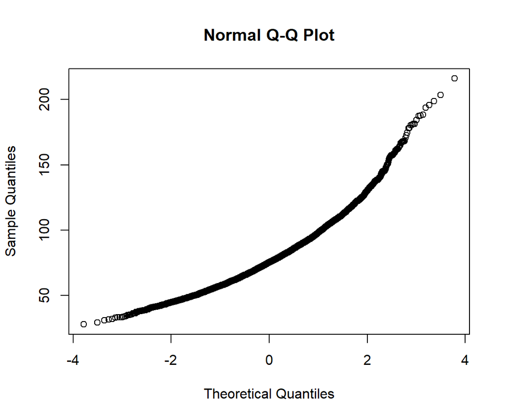

```r
# Let us have a look at the distribution of weight and height with a Q-Q-plot.
qqnorm(y = merged_nhanes$BMXWT)
```